# 第2回 線形回帰で学ぶ汎化性能とリークの再現

## 今日の分析目標

気温を入れると台数が出てくる1本の式を立て、その式がまだ来ていない日にどれだけ当たるかを測る。

もう1つのねらいは、式の記号をコードに1対1で写せるようになることです。そのために、便利な`fit()`の前に、1日ぶんの計算から自分で書きます。同じ計算を、`for`文で1日ずつ、numpyでまとめて、正規方程式、`fit()`の1行、と4つの書き方で書き、答えが同じになることを確かめながら進みます。

準備（Colabの使い方、道具の呼び出し、表の読み込み）から始めます。1日ぶんの計算から、731日ぶん・総当たり・正規方程式と積み上げて「良い直線」を選び、最後に`LinearRegression`の1行と比べます。そのあと、データを分けて本当の実力を測ります。最後の「目標に答えられたか」で振り返りましょう。

### 場面

あなたは自転車シェアの運営者で、毎晩、明日に向けて自転車を何台用意するかを決めます。

決めたいのは、気温などを入れると明日の台数が出てくる式です。その式が、まだ来ていない日にどれだけ当たるのかも知っておきたいところです。

### 手元のデータ

ある自転車シェアの2011年1月1日から2012年12月31日までの記録です（UCI Machine Learning RepositoryのBike Sharing Dataset）。1行が1日で、731日ぶんあります。行は日付の順に、過去から未来へ並んでいます。毎晩当てたいのは、その日の台数（`台数`）です。

気温と台数の散布図を描くと、2つのことが分かります。気温が高い日ほど台数が多く、ただし暑すぎると頭打ちになります。同じ気温でも、2年目のほうが多くなります。今日はおもに、`気温`（0〜1に縮めた値。1が約41℃）と`年`、そして`台数`を使います。

まず思いつく答え方は、条件の似た日の平均です。実際と答えの差の大きさを全日で平均したもの（外れ幅）で測ると、毎日同じ平均と答えれば1582台、気温帯と年で分けた平均なら762台外れます。ただ、この答えは気温帯の境目で跳ぶガタガタの段です。しかも、細かく分けるほど外れ幅は縮みます（月・年・天気・曜日で分けると408台）。でもそれは、平均を作るのに使った日で採点しているからです。今日は、この段を1本の式にします。

表をもう一度よく見ると、気になる列が2つあります。1つは`一般客`と`会員`の列で、足すと731日すべてでちょうど`台数`になります。明日の一般客と会員の数は、明日が来るまで分かりません。もう1つは`日付`で、表は過去から未来へ並んでいます。明日を当てたいのに、未来の日を見て学んでしまわないか、気をつける必要があります。この2つの列には、今日の後半で戻ってきます。

### 最後に出す答え

まだ来ていない日で測った式の当たり具合と、その式で見積もった明日の台数です。

## 学習ゴール

この回を終えると、次のことができるようになります。

- Colabでセルを上から実行し、ライブラリを呼び出して、表を読み込み、列名を付け替えられる
- 1日ぶんの予測・外れ・外れの二乗を計算し、`for`文で731日ぶん足し上げられる
- `for`文と`if`文の総当たりで二乗和の谷底を探し、最小二乗法（least squares）の考え方を説明できる
- 二乗和を微分して正規方程式を導き、numpyの行列の計算（`@`・`.T`・`np.linalg.inv`）でコードにできる。`LinearRegression`の答えと一致することを確かめられる
- R²を「毎日平均と答える基準から、外れの二乗和をどれだけ減らせたか」として計算できる
- データを訓練用とテスト用に分け、作るのに使ったデータでの成績と、まだ見ていないデータでの成績（汎化性能）を比べられる
- 答えに近い情報が手がかりに漏れ込む「リーク」を再現し、テストの成績が良すぎるときに疑える
- 式を曲げすぎたときの過学習（overfitting）を、訓練とテストのR²の差で説明できる

## 0. Colabと準備

問いが決まりました。式を作る前に、計算する場所と道具とデータを用意します。

ノートを開く 教材ページの表で、その回の「演習」列の［開く］をクリックすると、Colabでノートが開きます。開いたノートは、そのまま実行して使えます。ドライブへのコピーは要りません。Colabは、主要な道具（パッケージ）が最初からそろった環境をGoogleが用意しているサービスで、ブラウザを開くだけで全員が同じ環境になります。

セルを実行する ノートは、文章のセルとコードのセルの並びです。コードのセルは左の ▶ かShift + Enterで実行し、結果はすぐ下に出ます。終わるとセルの左に ✓ が付きます。最初の1回は、Colabの準備と道具の取り寄せで十数秒かかります。「このノートブックはGoogleが作成したものではありません」という警告が出たら、［このまま実行］を押します。教材のノートは、授業のために用意したものです。

プログラムは上から下へ 1つのセルの中は上の行から順に、ノートは上のセルから順に実行します。前のセルで作ったもの（読み込んだ表など）を、後のセルで使うからです。途中のセルを飛ばすと、後のセルは「そんな名前は知らない」と止まります。

エラーは、いちばん下の行を読む 赤い表示が出たら、いちばん下の行に原因が書いてあります。よく出るのは次の3つです。

- `NameError`：名前が見つからない。たいていは前のセルを飛ばした
- `ModuleNotFoundError`：使おうとした道具（ライブラリ）が入っていない
- `SyntaxError`：書き方の誤り。打ち間違い

それでも動かないとき ［ランタイム］→［ランタイムを再起動］で、それまでに実行したことをいったん忘れさせ、［ランタイム］→［すべてのセルを実行］で上から順にやり直します。

### お手本のセルの読み方

このノートでは、各節でまずお手本のセルを実行して読み方を確かめ、そのあとでそのセルを少し変えて広げていきます。セルは1行ずつ追うより、先に「何のためのかたまりか（役割）・何を受け取り（入力）・何を出すか（出力）」をつかむと読みやすくなります。

TODOを埋める TODOのセルにある`...`が、あなたが書く場所です。何を書くかはセルの前の文章に、手がかりはセルの中の「ヒント」のコメントにあります。たいていは、すぐ上のお手本のセルを少し変えれば書けます。

### 最初に実行する：道具を呼び出す

- 役割：このノートで使う道具（ライブラリ）を呼び出す
- 入力：なし
- 出力：なし（終わるとセルの左に ✓ が付く）

表を読む機能や図を描く機能は、Pythonの本体には入っていません。ライブラリと呼ぶ道具箱を足して使います。`import`は、その道具箱を持ってくる命令です。`import pandas as pd`は、表を扱うpandasを、`pd`という短い呼び名で使えるようにします。`from sklearn.linear_model import LinearRegression`のように`from`で始めると、道具箱の中から1つの道具だけを取り出し、`LinearRegression`という名前だけで呼べるようにします。

今日使う道具箱は4つです。

| 道具箱 | コードでの名前 | 使いみち |
| --- | --- | --- |
| numpy | `np` | 数の並び（配列）をまとめて計算する |
| pandas | `pd` | 表を読み、列を選ぶ |
| matplotlib | `plt` | 図を描く |
| scikit-learn | `sklearn` | 回帰の式を作り、データを分ける |

```python
import numpy as np
import pandas as pd
import matplotlib.pyplot as plt
from sklearn.linear_model import LinearRegression
from sklearn.model_selection import train_test_split
from sklearn.preprocessing import PolynomialFeatures
from sklearn.pipeline import Pipeline
```

### 図の日本語を表示できるようにする

- 役割：図の中の日本語が □ にならないようにし、図の大きさと字の大きさをそろえる
- 入力：なし
- 出力：「セットアップ完了」の表示

`!pip install`は、Colabに入っていない道具（ここでは図の日本語表示）を取り寄せる命令です。`#`から行の終わりまではコメントで、Pythonは読み飛ばします。人が読むためのメモです。`try:`から先は、日本語表示の道具が動かなくなったときの保険で、中身は読まなくてかまいません。最後の`print('セットアップ完了')`は、かっこの中を画面に表示する命令です。

```python
# 日本語が図の中で □ になるのを防ぐ
!pip install -q japanize-matplotlib
try:
    import japanize_matplotlib
# japanize が動かなくなったときの保険：同梱フォントを直接登録する
except Exception:
    from importlib.util import find_spec
    from matplotlib import font_manager as fm
    from pathlib import Path
    spec = find_spec('japanize_matplotlib')
    ttf = None
    if spec:
        ttf = next(Path(spec.origin).parent.rglob('*.ttf'), None)
    if ttf:
        fm.fontManager.addfont(str(ttf))
        name = fm.FontProperties(fname=str(ttf)).get_name()
        plt.rcParams['font.family'] = name

plt.rcParams['figure.figsize'] = (9, 5)
plt.rcParams['font.size'] = 13
plt.rcParams['axes.unicode_minus'] = False  # マイナス記号の化けを防ぐ
print('セットアップ完了')
```

```
セットアップ完了
```

### お手本：表を読み込んで、先頭を見る

- 役割：CSVファイルの表を読み込み、先頭の5行を見る
- 入力：データの置き場所`DATA_DIR`と、ファイル名`bike_day.csv`
- 出力：表`df`（このあと全部の節で使う）と、その先頭5行

`df = pd.read_csv(...)`は、右で読み込んだ表を、左の名前`df`にしまっておく書き方です。こうして名前を付けてしまっておくものを変数と呼びます。`pd.read_csv`は「pandasのread_csv」という関数で、CSVファイル（値をカンマで区切った表のファイル）を読みます。`df.head()`のように`df.`に続けて書くのは、表そのものが持っている機能（メソッド）の呼び出しです。

```python
# 自転車シェアの日次データ（1日1行）を読み込む
# データはこのリポジトリから読み込む
DATA_DIR = ('https://raw.githubusercontent.com/k0heiun0/'
            'applied_exercise_preview/main/shared/data')
df = pd.read_csv(f'{DATA_DIR}/bike_day.csv')
df.head()
```

|  | instant | dteday | season | yr | mnth | holiday | weekday | workingday | weathersit | temp | atemp | hum | windspeed | casual | registered | cnt |
| --- | --- | --- | --- | --- | --- | --- | --- | --- | --- | --- | --- | --- | --- | --- | --- | --- |
| 0 | 1 | 2011-01-01 | 1 | 0 | 1 | 0 | 6 | 0 | 2 | 0.344167 | 0.363625 | 0.805833 | 0.160446 | 331 | 654 | 985 |
| 1 | 2 | 2011-01-02 | 1 | 0 | 1 | 0 | 0 | 0 | 2 | 0.363478 | 0.353739 | 0.696087 | 0.248539 | 131 | 670 | 801 |
| 2 | 3 | 2011-01-03 | 1 | 0 | 1 | 0 | 1 | 1 | 1 | 0.196364 | 0.189405 | 0.437273 | 0.248309 | 120 | 1229 | 1349 |
| 3 | 4 | 2011-01-04 | 1 | 0 | 1 | 0 | 2 | 1 | 1 | 0.200000 | 0.212122 | 0.590435 | 0.160296 | 108 | 1454 | 1562 |
| 4 | 5 | 2011-01-05 | 1 | 0 | 1 | 0 | 3 | 1 | 1 | 0.226957 | 0.229270 | 0.436957 | 0.186900 | 82 | 1518 | 1600 |

1行が1日の記録で、列がその日の項目です。左端の0, 1, 2, …は行の番号です。pandasでは、このような表をDataFrame（データフレーム）と呼びます。`df`は、その頭文字から付けた名前です。当てたい値は`cnt`（その日の利用台数）です。

### 前処理：列名を日本語にする

`season`・`yr`・`cnt`のような英語の略称は、何の列かすぐには読めません。前処理として、列名を日本語に付け替えてから使います。

- 役割：英語の列名を日本語に付け替え、先頭5行を見る
- 入力：表`df`
- 出力：列名が日本語になった表`df`

`{'元の名前': '新しい名前', ...}`のように組を並べたものを、辞書（dictionary）と呼びます。`rename(columns=ja_names)`は、この対応どおりに列名を付け替えます。値は変わりません。

```python
ja_names = {'instant': '番号', 'dteday': '日付', 'season': '季節',
            'yr': '年', 'mnth': '月', 'holiday': '祝日',
            'weekday': '曜日', 'workingday': '平日',
            'weathersit': '天気', 'temp': '気温', 'atemp': '体感気温',
            'hum': '湿度', 'windspeed': '風速', 'casual': '一般客',
            'registered': '会員', 'cnt': '台数'}
df = df.rename(columns=ja_names)
df.head()
```

|  | 番号 | 日付 | 季節 | 年 | 月 | 祝日 | 曜日 | 平日 | 天気 | 気温 | 体感気温 | 湿度 | 風速 | 一般客 | 会員 | 台数 |
| --- | --- | --- | --- | --- | --- | --- | --- | --- | --- | --- | --- | --- | --- | --- | --- | --- |
| 0 | 1 | 2011-01-01 | 1 | 0 | 1 | 0 | 6 | 0 | 2 | 0.344167 | 0.363625 | 0.805833 | 0.160446 | 331 | 654 | 985 |
| 1 | 2 | 2011-01-02 | 1 | 0 | 1 | 0 | 0 | 0 | 2 | 0.363478 | 0.353739 | 0.696087 | 0.248539 | 131 | 670 | 801 |
| 2 | 3 | 2011-01-03 | 1 | 0 | 1 | 0 | 1 | 1 | 1 | 0.196364 | 0.189405 | 0.437273 | 0.248309 | 120 | 1229 | 1349 |
| 3 | 4 | 2011-01-04 | 1 | 0 | 1 | 0 | 2 | 1 | 1 | 0.200000 | 0.212122 | 0.590435 | 0.160296 | 108 | 1454 | 1562 |
| 4 | 5 | 2011-01-05 | 1 | 0 | 1 | 0 | 3 | 1 | 1 | 0.226957 | 0.229270 | 0.436957 | 0.186900 | 82 | 1518 | 1600 |

ここから先は、日本語の名前で列を選びます。各列の中身は次のとおりです。

| 元の名前 | 日本語の名前 | 中身 |
| --- | --- | --- |
| `instant`・`dteday` | `番号`・`日付` | 通し番号と、その日の日付 |
| `season` | `季節` | 1〜4の区分の番号 |
| `yr` | `年` | 0＝2011年、1＝2012年 |
| `mnth` | `月` | 1〜12 |
| `holiday`・`workingday` | `祝日`・`平日` | 祝日なら1、平日なら1（ちがえば0） |
| `weekday` | `曜日` | 0〜6 |
| `weathersit` | `天気` | 1＝晴れ〜3＝雨・雪 |
| `temp`・`atemp` | `気温`・`体感気温` | 0〜1に縮めた値（気温は41を掛けると℃） |
| `hum`・`windspeed` | `湿度`・`風速` | 0〜1に縮めた値 |
| `casual`・`registered` | `一般客`・`会員` | その日の一般客と会員の台数 |
| `cnt` | `台数` | その日の利用台数（当てたい値） |

### 分析の地図：今日はここ

データ解析は「① データの理解と目標の設定 → ② 前処理（preprocessing）とデータ解析 → ③ 結果の解釈と目標との整合」の3つのフェーズを回ります。今日は ② の解析が中心です。

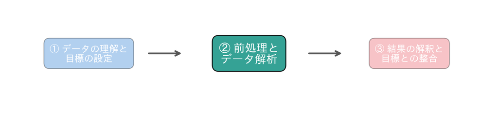

### 今日の道筋

段を1本の式にし、その式がまだ来ていない日にも当たるかを確かめます。次の5つの小さな問いに、順に答えていきます。

1. 直線の良さを、どう測る？（1〜3節）
2. いちばん良い直線は？（4〜5節）
3. まだ見ていない日に、当たる？（6節）
4. 曲げれば、もっと当たる？（7節）
5. 明日は、何台？（8節）

## 1. 列を数の並びとして取り出す

表が読めました。今日は、似た日の平均の段を1本の式に置き換えます。式を立てるには、気温と台数を「1日ずつの数の並び」として扱えると便利です。

### 表から、列を1本選ぶ

表から1つの列を取り出すには、`[ ]`に列名を入れます。

```python
df['台数']        # 台数の列だけ
```

取り出したものは、日付の番号つきの列（Series）です。

### お手本：列を配列にして、1日目を見る

- 役割：気温と台数の列を、数の並び（配列）として取り出し、1日目の値を見る
- 入力：表`df`
- 出力：配列`x`（気温）と`y`（台数）

`.values`を付けると、列がnumpyの配列（array）になります。配列は`x[0]`のように番号で1つずつ取り出せます。番号は0から数えます。`len(x)`は、並んでいる数の個数を返します。`print()`は0節で見たとおり、かっこの中を表示します。

```python
x = df['気温'].values     # 気温（731日ぶん）
y = df['台数'].values      # 台数（731日ぶん）
print(len(x))             # いくつ並んでいるか
print(x[0])               # 1日目の気温
print(y[0])               # 1日目の台数
```

```
731
0.344167
985
```

731個の数が並んでいます。1日目は、気温0.344（41を掛けると約14.1℃）で、台数は985台でした。

## 2. 1日目を直線で予測すると？

1節で、1日目の気温と台数を取り出せました。似た日の平均の段の代わりに、いちばん単純な式を考えます。直線です。

$$\text{台数} \approx a \times \text{気温} + b$$

記号で書くと、$i$日目の気温（0〜1に縮めた値）を$x_i$、台数を$y_i$、直線による予測を$\hat{y}_i$（ワイ・ハット。ハットは「予測」の印）として、

$$\hat{y}_i = a\,x_i + b \qquad (i = 1, 2, \dots, 731)$$

`気温`は、実際の気温（℃）を41で割って0〜1に縮めた値です。実際の気温を$t_i$とすると$x_i = t_i/41$なので、$\hat{y}_i = \frac{a}{41}\,t_i + b$と書けます。a（傾き）は、`気温`が1増えたときに台数がいくら増えるか。1℃あたりの増え方は$a/41$です（a=6600なら1℃で約160台）。b（切片）は、`気温`が0のときの台数です。aとbの2つの数を決めれば、式が完成します。このように直線（1次式）の式で当てることを、線形回帰（linear regression）と呼びます。でも、aとbの組み合わせは無数にあります。どれが「良い直線」なのでしょうか。まずは適当なaとbで、1日目だけを予測してみます。

### お手本：1日目の予測と外れ

- 役割：a=9000・b=0の直線で1日目を予測し、外れ（実際 − 予測）とその二乗を出す
- 入力：`x[0]`・`y[0]`と、a・b
- 出力：予測・外れ・外れの二乗

予測が実際からどれだけずれたか、$e_i = y_i - \hat{y}_i$を残差（residual）と呼びます。外れは多すぎても少なすぎても困るので、符号を消すために二乗します。二乗にはもう1つ良さがあります。aやbを動かすと、二乗の和はなめらかな谷の形になります。そのため、あとで見るように谷底を式一発で求められるのです（4節・5節）。大きく外れた日ほど重く数えられるという性質もあります。

```python
a = 9000
b = 0
pred = a * x[0] + b       # 1日目の予測
print(pred)
err = y[0] - pred         # 外れ（実際 − 予測）
print(err)
print(err ** 2)           # 外れの二乗
```

```
3097.503
-2112.503
4462668.925009001
```

予測は約3098台。実際は985台なので、外れは −2112.5台（多く見積もりすぎた）、その二乗は約446万です。

### TODO①：2日目と3日目も、同じように計算する

上のお手本のセルをコピーして、`x[0]`・`y[0]`を2日目（`[1]`）と3日目（`[2]`）に変え、予測・外れ・外れの二乗を表示してください。TODOのセルの`...`を消して、そこに書きます。お手本のコードを選んでコピーし、TODOのセルに貼り付けてから書き換えると楽です。

```python
# TODO: 上のセルをコピーして、[0] を [1]（2日目）と
#       [2]（3日目）に変えて表示する
# ヒント: 2日目の分と3日目の分を、続けて書けばよい
...;
```

2日目の外れは −2470.3、3日目は −418.3です。同じことを731日ぶん書くのは大変です。次の節で、繰り返しを書く方法を使います。

## 3. 731日ぶんを足し上げる

直線の良さを測るには、1日だけでなく、全部の日の外れを見る必要があります。外れの二乗を全日で足した二乗和を、直線の物差しにします。小さいほど、よく当たる直線です。

$$S(a, b) = \sum_{i=1}^{731} \bigl(y_i - (a\,x_i + b)\bigr)^2$$

$\sum$は、$i=1$から731までを足し上げる記号です。aとbを決めると二乗和が1つに決まるので、$S(a, b)$と書きます。下の`for`文は、この$\sum$の1項ずつを足していきます。

### お手本：for文で足し上げる

- 役割：731日ぶんの外れの二乗を、1日ずつ足し上げる
- 入力：配列`x`・`y`と、a・b
- 出力：二乗和`total`

`for i in range(len(x)):`は、「`i`を0, 1, 2, …, 730と変えながら、下の字下げした行を繰り返す」という書き方です（for文）。字下げ（行の頭のすきま）が、繰り返す範囲の目印です。`total = total + …`は、「いまの合計に足して、合計を更新する」という意味です。

```python
total = 0
for i in range(len(x)):
    pred = a * x[i] + b                  # その日の予測
    total = total + (y[i] - pred) ** 2   # 外れの二乗を足す
print(total)
```

```
1798539709.665675
```

二乗和は約18.0億です。2節で計算した1日目の446万は、この中の1日ぶんです。

### 変えてみる：numpyで、まとめて計算する

numpyの配列は、`for`文を書かなくてもまとめて計算できます。`a * x + b`と書くと、731日ぶんの予測が一度に出ます。`.sum()`は全部を足すメソッドです。

`residual[:3]`は、配列の番号0・1・2の3つを取り出す書き方です（スライス）。`[始め:終わり]`の形で、始めを省くと0から、終わりの番号は含みません。

```python
residual = y - (a * x + b)       # 731日ぶんの外れを、まとめて
print(residual[:3])              # 最初の3日ぶん
print((residual ** 2).sum())     # 二乗して、全部足す
```

```
[-2112.503 -2470.302  -418.276]
1798539709.665673
```

最初の3日ぶんは、2節とTODO①で1日ずつ計算した値と同じです。二乗和も`for`文の答えと一致しました。`for`文で書いたことを、numpyは1行でやってくれていたのです。

実務では、`for`文で1日ずつ足し上げることはしません。numpyの1行のほうが速く、書き間違いも少ないからです。ここで`for`文で書いたのは、$\sum$の1項ずつを目で見るためでした。

## 4. いちばん良いaとbは？ 総当たりで探す

二乗和がいちばん小さくなるaとbを探します。まずは素朴に、aをいろいろ試してみます。

### お手本：aを100ずつ試す

- 役割：bを1200に固定し、aを5000〜8000まで100ずつ変えて、二乗和がいちばん小さいaを探す
- 入力：配列`x`・`y`
- 出力：いちばん良いaと、そのときの二乗和

`range(5000, 8001, 100)`のように数を3つ渡すと、`range(始め, 終わり, 刻み)`の意味になり、始めから刻みずつ増えていきます。終わりの数は含まないので、8000まで入れたいときは8001と書きます。まず、小さな範囲で確かめてみましょう。

```python
for a in range(5000, 5301, 100):
    print(a)          # 5000, 5100, 5200, 5300 と表示される
```

```
5000
5100
5200
5300
```

`if`文は「条件が成り立つときだけ、下の字下げした行を実行する」書き方です（if文）。ここでは「これまでの最小より小さければ、覚え直す」に使います。`None`は「まだ何も入っていない」という印で、1回目は必ず覚えます。`A or B`は「AとBのどちらかが成り立てば成り立つ」という意味です。1回目は`best_sse is None`で成り立ち、2回目からは`s < best_sse`で決まります。

```python
best_a = None
best_sse = None
for a in range(5000, 8001, 100):              # 5000, 5100, …, 8000
    s = ((y - (a * x + 1200)) ** 2).sum()     # この a の二乗和
    if best_sse is None or s < best_sse:      # 小さければ覚え直す
        best_a = a
        best_sse = s
print(best_a, best_sse)
```

```
6700 1661091384.2666712
```

a=6700のとき、二乗和が最小になりました。aを動かしたときの二乗和を図にすると、谷底が1つだけのU字になります。

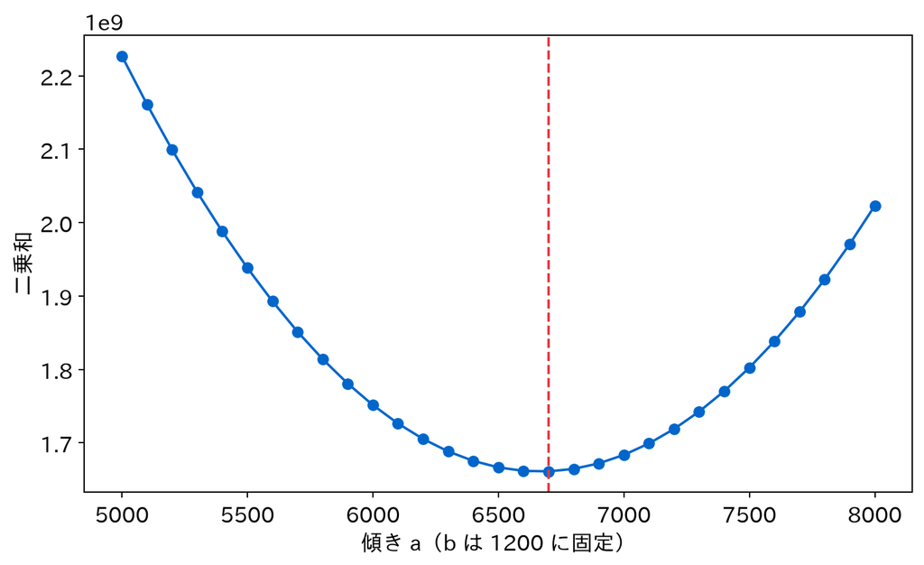

### 変えてみる：bも動かす（for文を二重に）

上のセルの`1200`を、もう1つの`for`文の`b`に変えます。`for`文の中に`for`文を入れると、aとbのすべての組み合わせを試せます。`best`には (a, b, 二乗和) の3つをまとめて覚えます。`best[2]`は3つ目、つまり二乗和です。

```python
best = None
for a in range(5000, 8001, 100):
    for b in range(0, 2001, 100):          # b も動かす
        s = ((y - (a * x + b)) ** 2).sum()
        if best is None or s < best[2]:
            best = (a, b, s)
print(best)
```

```
(6700, 1200, np.float64(1661091384.2666712))
```

31×21 ＝ 651通りを試して、a=6700・b=1200が選ばれました。

### TODO②：範囲を狭めて、刻みを細かくする

上の二重の`for`文のセルをコピーして、aを6400〜6800、bを1000〜1400の範囲で、どちらも10ずつ試すように変えてください。

```python
# TODO: 上のセルをコピーして、a を range(6400, 6801, 10)、
#       b を range(1000, 1401, 10) にする
# ヒント: 変えるのは range の中の数だけ
...;
```

## 5. 谷底を式一発で求める

谷底への道は2つあります。正規方程式という式で解く道と、`fit()`に任せる道です。着くのは同じ谷底です。この節では一度だけ式の道を通り、`fit()`と同じ所に着くことを確かめます。

同じ二乗和の計算を、ここまでに`for`文（1日ずつ）とnumpy（まとめて）で書きました。この節の正規方程式と`fit()`の1行を合わせると、書き方は4段の階段になります。上の段ほど書く量が少なく、中身はライブラリに任せます。どの段でも、答えは同じです。

総当たりは、刻みを細かくするほど時間がかかります。実は、二乗和の谷底は式一発で求められます。谷底では、aやbを少し動かしても二乗和は変わりません。つまり、$S(a, b)$をaで微分しても、bで微分しても0になります（$\partial$は、ほかの文字を止めて微分する、という印）。

$$\frac{\partial S}{\partial a} = \sum_{i=1}^{731} -2\,x_i\,\bigl(y_i - a\,x_i - b\bigr) = 0, \qquad
\frac{\partial S}{\partial b} = \sum_{i=1}^{731} -2\,\bigl(y_i - a\,x_i - b\bigr) = 0$$

$-2$で割って、aとbを含む項を左に集めると、2本の式になります（$n = 731$）。

$$\begin{aligned}
n\,b + \Bigl(\sum_i x_i\Bigr)\,a &= \sum_i y_i \\
\Bigl(\sum_i x_i\Bigr)\,b + \Bigl(\sum_i x_i^2\Bigr)\,a &= \sum_i x_i\,y_i
\end{aligned}$$

知りたいのはaとbの2つで、式も2本です。連立方程式として解けます。

### 行列で書く：正規方程式

この2本の式は、行列で1本にまとめられます。台数を縦に並べた$\mathbf{y}$（731×1）、1の列と気温の列を並べた表$\mathbf{X}$（731×2）、切片と傾きを並べた$\boldsymbol{\beta} = (b, a)^\top$（2×1）を使うと、予測は$\mathbf{X}\boldsymbol{\beta}$で731日ぶんがまとめて出ます。そして、上の2本の式は

$$\underbrace{\begin{pmatrix} n & \sum_i x_i \\ \sum_i x_i & \sum_i x_i^2 \end{pmatrix}}_{\mathbf{X}^\top\mathbf{X}}
\begin{pmatrix} b \\ a \end{pmatrix}
=
\underbrace{\begin{pmatrix} \sum_i y_i \\ \sum_i x_i\,y_i \end{pmatrix}}_{\mathbf{X}^\top\mathbf{y}}$$

を書き下したものです。これを$\mathbf{X}^\top\mathbf{X}\boldsymbol{\beta} = \mathbf{X}^\top\mathbf{y}$と書き、正規方程式（normal equation）と呼びます。答えは

$$\hat{\boldsymbol{\beta}} = \bigl(\mathbf{X}^\top\mathbf{X}\bigr)^{-1}\mathbf{X}^\top\mathbf{y}$$

の1行です。$(\cdot)^{-1}$は逆行列（inverse matrix）で、掛けると1にあたる行列（単位行列）になる行列です。$\mathbf{X}$の列が何本になっても、同じ式で谷底が出ます。外れの二乗和を最小にして係数を決めるこのやり方を、最小二乗法と呼びます。

### お手本：正規方程式をコードにする

- 役割：正規方程式を、記号と1対1でコードにする
- 入力：配列`x`・`y`
- 出力：$\hat{\boldsymbol{\beta}}$（`beta`）と、切片`b_best`・傾き`a_best`

転置$\mathbf{X}^\top$は`X1.T`、行列の積は`@`、逆行列は`np.linalg.inv`です。`np.ones(731)`は1が731個並んだ配列で、`np.column_stack`は配列を列として横に並べ、表（行列）にします。

```python
X1 = np.column_stack([np.ones(len(x)), x])  # 1の列と、気温の列
A = X1.T @ X1                 # XᵀX
c = X1.T @ y                  # Xᵀy
beta = np.linalg.inv(A) @ c   # (XᵀX)⁻¹ Xᵀy
b_best, a_best = beta         # 切片と傾き
print(beta)
```

```
[1214.64211903 6640.70999855]
```

b=1214.64、a=6640.71。TODO②の総当たりの谷底（6650, 1210）のすぐ近くが、正確な谷底でした。

### fit() の中身も、同じ谷底

scikit-learnの`LinearRegression`も、この最小二乗法を中でやってくれる道具です。`LinearRegression()`で式の入れ物を作り、`fit`で学ばせ、`coef_`（傾き）と`intercept_`（切片）で結果を見ます。列は`df[['気温']]`のように二重のかっこで渡します。外のかっこが列を選ぶ`[ ]`、中のかっこが列名の並び（リスト）です。1列でも表の形のまま取り出せます。`fit`は手がかりを表の形で受け取るので、この形にします。

```python
model_temp = LinearRegression()
model_temp.fit(df[['気温']], y)
print(model_temp.coef_[0])           # 傾き a
print(model_temp.intercept_)         # 切片 b
```

```
6640.709998548634
1214.6421190294031
```

自分で書いた正規方程式の答えと一致しました。`fit()`の1行の中身は、いま自分で書いた計算と同じ谷底です。

### 変えてみる：R²を自分で計算する

当たり具合の物差しとして、R²（決定係数）を使います。「毎日平均と答えたときの二乗和（基準）のうち、直線でどれだけ減らせたか」の割合で、1に近いほどよく当たります。

$$R^2 = 1 - \frac{\sum_i (y_i - \hat{y}_i)^2}{\sum_i (y_i - \bar{y})^2}$$

分子が直線の二乗和、分母が毎日平均$\bar{y}$と答えたときの二乗和です。直線が平均より外れれば、分数が1を超えて、R²はマイナスになります。コードの`y.mean()`は、配列の平均を出すメソッドです。`score`は、渡したデータでのR²を返します。

```python
pred_line = a_best * x + b_best
sse_line = ((y - pred_line) ** 2).sum()      # 直線の二乗和
sst = ((y - y.mean()) ** 2).sum()            # 基準の二乗和
print(1 - sse_line / sst)                    # R²
print(model_temp.score(df[['気温']], y))     # 答え合わせ
```

```
0.3937487313729242
0.3937487313729241
```

R²は0.394。基準の二乗和のうち、約4割を気温の直線で減らせました。

手がかりを増やすこともできます。`df[['気温', '年']]`のように列を並べるだけで、気温と年を両方使う式（重回帰、multiple regression）になります。年を$x_{i2}$とすると、$\hat{y}_i = a_1 x_{i1} + a_2 x_{i2} + b$です。

```python
model_ty = LinearRegression()
model_ty.fit(df[['気温', '年']], y)
print(model_ty.coef_, model_ty.intercept_)
print(model_ty.score(df[['気温', '年']], y))
```

```
[6369.64490081 2083.23997526] 305.8787327748878
0.6825991406100751
```

気温と年を使うと、R²は0.68まで上がりました。`coef_`に並ぶ各列に掛かる数（直線の傾きaにあたる数）を、係数と呼びます。

### 変えてみる：11本の列の表を作る

列を11本に増やしても、変わるのは$\mathbf{X}$の列の数だけです（731×12）。正規方程式のコードは、そのまま使えます。1の列に11本の列を並べた表を作ります。`df[cols].values`で、11列をまとめて配列にします。

```python
cols = ['季節', '年', '月', '祝日', '曜日', '平日',
        '天気', '気温', '体感気温', '湿度', '風速']
X11 = np.column_stack([np.ones(len(y)), df[cols].values])
print(X11.shape)
```

```
(731, 12)
```

### TODO③：11本の列で正規方程式を解く

`X11`で正規方程式を作り、お手本と同じ`np.linalg.inv`で$\hat{\boldsymbol{\beta}}$を求めて表示してください。出てくる係数は12個（切片1個と、11本の列の係数）です。

```python
# TODO: X11 で正規方程式を作り、β を求めて表示する
# ヒント: お手本の X1 を X11 に変え、最後に print する
...;
```

### 変えてみる：同じことを1行で

`LinearRegression`なら、1の列を自分で足してくれるので、`df[cols]`を渡すだけです。

```python
model11 = LinearRegression().fit(df[cols], y)
print(round(model11.intercept_, 2))
print(model11.coef_.round(2))
```

```
1469.0
[  509.78  2040.7    -38.98  -518.99    69.06   120.36  -610.99  2028.92
  3573.27 -1018.86 -2557.57]
```

正規方程式を自分で書いた12個の係数と、1行の答えが一致します。中で何をしているかを知ったうえで、1行で済ませられる。これがライブラリの便利さです。

### 式の道は、何のため？

普段のデータ解析なら、`fit()`の1行で十分です。6節から先は、`fit()`で進みます。

では、式の道を通ったのは何のためでしょうか。この節でやったのは、式の記号をコードに1対1で写すことでした。これができると、式とコードを行き来できます。結果がおかしいとき、`fit()`の中で何が起きたかを疑えます。教科書や論文の式を読んで、コードで確かめることもできます。

`fit()`の中身も、誰かが式からこうして書いたものです。新しい手法やライブラリを作る人は、この対応づけを毎回やっています。使うだけなら`fit()`、作るなら式からコードへ、です。

## 6. 自己採点は甘くないか

ここまでのR²は、式を作るのに使った731日で測っていました。導入で見たとおり、作るのに使った日で採点すると、成績は甘く出ます。本当の実力は、まだ見ていない日で測る必要があります。

そこで、データを2つに分けます。式を作るのに使う訓練データ（過去問）と、最後まで取っておくテストデータ（本番）です。まず、導入で見た似た日の平均の段で試してみます。

```python
# @title 似た日の平均の段を、作った日と、まだ見ていない日で採点する
d = df.copy()
d['気温帯'] = pd.cut(d['気温'] * 41, bins=[0, 10, 15, 20, 25, 30, 40])
tr, te = train_test_split(d, test_size=0.2, random_state=42)
for keys in [['気温帯', '年'], ['月', '年', '天気', '曜日']]:
    means = tr.groupby(keys, observed=True)['台数'].mean().rename('答え')
    pred_tr = tr.join(means, on=keys)['答え']
    pred_te = te.join(means, on=keys)['答え']
    ok = pred_te.notna()             # 訓練に同じ組み合わせがあり、答えを出せた日
    err_tr = np.abs(tr['台数'] - pred_tr)
    err_te = np.abs(te['台数'] - pred_te)
    print(keys)
    print('  作った日          :', round(err_tr.mean()), '台')
    print('  答えを出せない日  :', int((~ok).sum()), '日')
    print('  答えを出せた日    :', round(err_te[ok].mean()), '台')
```

```
['気温帯', '年']
  作った日          : 766 台
  答えを出せない日  : 0 日
  答えを出せた日    : 773 台
['月', '年', '天気', '曜日']
  作った日          : 393 台
  答えを出せない日  : 45 日
  答えを出せた日    : 665 台
```

気温帯×年の段は、作った日でも見ていない日でも、外れ幅は770台ほどで変わりません（訓練の584日だけで段を作り直したので、731日すべてで作った導入の762台とは少し違います）。

### 考えてみよう：細かい段は、どうなる？

月×年×天気×曜日の細かい段は、作った日では393台しか外れません。上の出力の下半分を見る前に、まだ見ていない147日で試すと何が起きそうかを予想して、下に書いてください。

（ここに予想を書く）

テスト147日のうち45日は、訓練に同じ組み合わせ（同じ月・年・天気・曜日）の日が1日もありません。その日には、段の答えそのものが出せないのです。答えを出せた102日だけで見ても、外れ幅は665台あり、作った日の393台よりずっと大きくなります。細かく分けた段は、作った日の台数を覚えていただけで、新しい組み合わせの日には答えを持っていなかったのです。（`~ok`の`~`は、TrueとFalseを入れかえる記号です。）

### お手本：データを訓練とテストに分ける

- 役割：11本の列を手がかりに、データを訓練8割・テスト2割に分ける
- 入力：手がかりの表`X`と台数`y`
- 出力：`X_tr`・`X_te`・`y_tr`・`y_te`

`train_test_split`は、行をばらばらに混ぜてから分ける関数です。`test_size=0.2`でテストを2割に、`random_state=42`で混ぜ方を固定します（何度やっても同じ分け方になる）。

```python
cols = ['季節', '年', '月', '祝日', '曜日', '平日',
        '天気', '気温', '体感気温', '湿度', '風速']
X = df[cols].values
X_tr, X_te, y_tr, y_te = train_test_split(X, y, test_size=0.2,
                                          random_state=42)
print(len(X_tr), len(X_te))
```

```
584 147
```

訓練が584日、テストが147日になりました。まだ見ていないテストでの当たり具合を、汎化性能（generalization performance）と呼びます。

### TODO④：訓練で学び、訓練とテストのR²を比べる

`LinearRegression`を訓練データだけで`fit`し、`score`で訓練データのR²とテストデータのR²を表示してください。

```python
# TODO: 訓練データだけで fit し、訓練の R² とテストの R² を表示する
# ヒント: model = LinearRegression().fit(X_tr, y_tr) のあと、
#         model.score(X_tr, y_tr) と model.score(X_te, y_te)
...;
```

訓練のR²は0.791、テストのR²は0.828です。2つがほぼ同じです（テストがたまたま少し高い）。つまり、この直線の式は作った日を覚えすぎておらず、まだ見ていない日にも同じくらい当たるということです。汎化性能は、訓練並みです。

### 考えてみよう：完璧すぎる式

11本の列に、ある2列を足すと、まだ見ていないテストのR²がちょうど1.0になります。どの日もぴったり当たるのです。どの2列で、なぜそうなるのか、どこがおかしいのかを、導入の「手元のデータ」を思い出して予想し、下に書いてください。

（ここに予想を書く）

### 変えてみる：リークを再現する

導入で見たとおり、`一般客`と`会員`は、足すとちょうど台数になる内訳です。わざとこの2列を手がかりに足すと、どうなるでしょうか。上のお手本の`cols`に`+`で2列をつなぎ、分け方も同じにします。

```python
cols_leak = cols + ['一般客', '会員']
X_leak = df[cols_leak].values
XL_tr, XL_te, yL_tr, yL_te = train_test_split(
    X_leak, y, test_size=0.2, random_state=42)
model_leak = LinearRegression().fit(XL_tr, yL_tr)
print('テスト R²:', model_leak.score(XL_te, yL_te))
```

```
テスト R²: 1.0
```

まだ見ていないテストでも、R²は1.0。どの日もぴったり当たりました。台数＝一般客＋会員なので、一般客と会員の係数を1、ほかを0にすれば、外れは0になります。答えそのものを手がかりに入れていたのです。このように、答え（やそれに近い情報）が手がかりに漏れ込むことを、リーク（leakage、情報の漏れ）と呼びます。訓練とテストに分けても、両方に同じ漏れがあるので見抜けません。

明日の一般客と会員の数は、明日が来るまで分かりません。この式は、明日の台数を当てるのには使えないのです。テストの成績が良すぎるときは、まずリークを疑います。

## 7. 式を曲げすぎると？

6節で、直線の式は訓練とテストでほぼ同じくらい当たると分かりました。直線が暑い日の頭打ちを外すなら、式を曲げればよいのでは？ 気温の2乗、3乗……を足していくと、式は曲線になります（多項式回帰）。$\hat{y} = b + a_1 x + a_2 x^2 + \cdots + a_d x^d$の、何乗まで使うか（$d$）を次数と呼びます。曲げるほど、訓練データにはよく当たるはずです。では、テストデータには？

### お手本：3次の曲線を当てはめる

- 役割：気温だけを手がかりに、3次の曲線を訓練データで学び、訓練とテストのR²を出す
- 入力：訓練とテストの気温・台数
- 出力：2つのR²

`X_tr[:, [7]]`の`:`はすべての行、`[7]`は8本目の列（番号は0から）を表します。`[7]`とかっこで囲むと、1列の表の形のまま取り出せます。`fit`は手がかりを表の形で受け取るので、この形にしておきます。

`PolynomialFeatures(3)`は気温から2乗・3乗の列を作る部品、`Pipeline`は部品を順につなぐ道具です。

```python
x1_tr = X_tr[:, [7]]    # 8本目の列（気温）だけ
x1_te = X_te[:, [7]]
model3 = Pipeline([('poly', PolynomialFeatures(3)),
                   ('lr', LinearRegression())])
model3.fit(x1_tr, y_tr)
print(model3.score(x1_tr, y_tr), model3.score(x1_te, y_te))
```

```
0.4720415505498843 0.4137499258721813
```

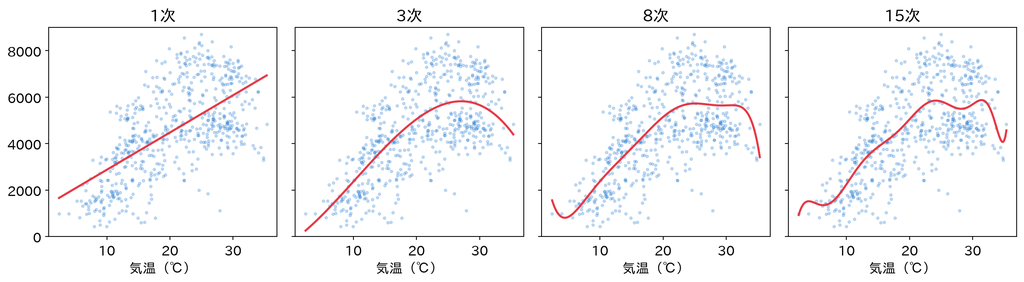

### TODO⑤：次数を変えて、訓練とテストのR²を並べる

`for`文で次数を1・3・8・15と変えながら、お手本のセルと同じことをして、次数ごとの訓練のR²とテストのR²を表示してください。

```python
# TODO: for deg in [1, 3, 8, 15]: として、次数ごとの
#       訓練 R² とテスト R² を表示する
# ヒント: お手本の PolynomialFeatures(3) の 3 を deg に変え、
#         4つの行を for の中に入れる
...;
```

訓練のR²は次数とともに上がっていきます（0.388 → 0.472 → 0.476 → 0.481）。テストのR²は0.404 → 0.414 → 0.408 → 0.407で、3次がいちばん高いものの、ほぼ横ばいです。訓練が584日もあると、曲線は1日1日の偶然の揺れに振り回されにくく、曲げすぎてもテストの成績はほとんど崩れません。

では、データが少なかったらどうでしょう。

### 考えてみよう：20日だけなら？

訓練を584日から20日に減らし、テストは同じ147日のままで、1次・3次・8次と曲げていきます。訓練のR²とテストのR²は、それぞれどう動くと思いますか。予想を下に書いてから、次のセルを実行してください。

（ここに予想を書く）

### 変えてみる：訓練を20日だけにする

- 役割：訓練データを最初の20日だけにして、1・3・8次の曲線を学び、訓練とテストのR²を出す
- 入力：訓練の最初の20日（`x1_tr[:20]`・`y_tr[:20]`）と、テストの147日
- 出力：次数ごとの、訓練のR²とテストのR²

`[:20]`は、3節で見たスライスです。番号0〜19の20日を取り出します。テストは同じ147日のままです。

```python
x20 = x1_tr[:20]     # 訓練の最初の20日だけ
y20 = y_tr[:20]
for deg in [1, 3, 8]:
    m = Pipeline([('poly', PolynomialFeatures(deg)),
                  ('lr', LinearRegression())])
    m.fit(x20, y20)
    print(deg, '次:', round(m.score(x20, y20), 3),
          round(m.score(x1_te, y_te), 3))
```

```
1 次: 0.228 0.362
3 次: 0.444 -0.288
8 次: 0.499 -28.353
```

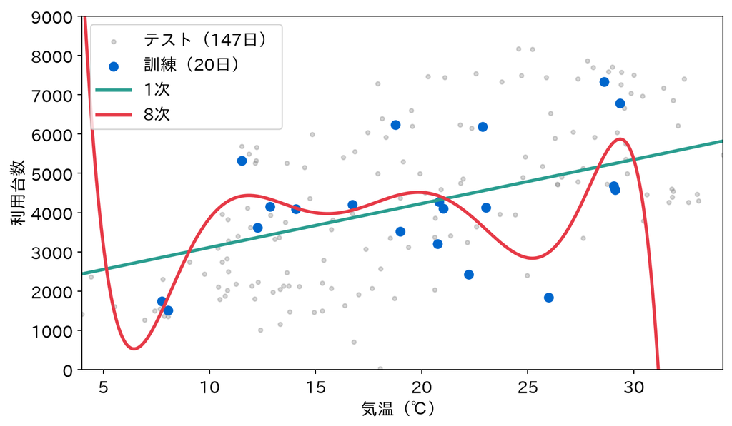

訓練のR²は0.228 → 0.444 → 0.499と、曲げるほど上がります。ところがテストのR²は0.362 → −0.288 → −28.353と、マイナスに落ちました。R²のマイナスは、毎日平均と答えるより悪いということです。図を見ると、8次の曲線は青い20日に合わせて曲がり、20日の外（8℃未満や29℃超）では大きく外れています。

曲げすぎた式は、訓練データの偶然の揺れまで覚えてしまいます。これが過学習です。データが多いと目立ちませんが、少ないほどはっきり出ます。

## 8. 明日は何台？

6節で、11本の列の式は、まだ見ていない日にも同じくらい当たると分かりました。ただ、明日の湿度や風速は、まだ分かりません。明日に答えるのは、5節の気温と年の2つを使った式にします。まず、この式も6節と同じ分け方で測ります。6節のお手本の`X`を、2本の列の`Xty`に変えただけです。

```python
Xty = df[['気温', '年']].values
Xty_tr, Xty_te, yty_tr, yty_te = train_test_split(
    Xty, y, test_size=0.2, random_state=42)
model_ty = LinearRegression().fit(Xty_tr, yty_tr)
print('訓練 R²  :', model_ty.score(Xty_tr, yty_tr))
print('テスト R²:', model_ty.score(Xty_te, yty_te))
```

```
訓練 R²  : 0.6727204673783596
テスト R²: 0.7128404660904721
```

テストのR²は0.713で、11本の列の0.828より低くなりました。手がかりを減らしたぶん、外れます。その代わり、明日に使える式になりました。

次に、作った日と、まだ見ていない日の外れ幅の平均$\frac{1}{n}\sum_i |y_i - \hat{y}_i|$を測ります。明日が27℃・2年目なら、何台でしょうか。

```python
err_tr = np.abs(yty_tr - model_ty.predict(Xty_tr)).mean()
err_te = np.abs(yty_te - model_ty.predict(Xty_te)).mean()
print('作った日の外れ幅  :', round(err_tr), '台')
print('まだ見ていない日  :', round(err_te), '台')
pred_t = model_ty.predict([[27 / 41, 1]])[0]     # 27℃・2年目
print('明日（27℃・2年目）:', round(pred_t), '台')
```

```
作った日の外れ幅  : 859 台
まだ見ていない日  : 837 台
明日（27℃・2年目）: 6565 台
```

`predict`に手がかりの表を渡すと、予測が返ります。`[[27 / 41, 1]]`は1行の表で、気温は41で割った値、年は2年目なので1です。式に代入しているだけで、$\hat{y} = a_1 \cdot \frac{27}{41} + a_2 \cdot 1 + b$を計算しています。予測は並びで返るので、`[0]`で1つ目を取り出します。

答えは「およそ6600台。まだ見ていない日での外れ幅は、平均840台くらい」です。

似た日の平均で答えると、25〜30℃・2年目の晴れの日（54日）の平均で、およそ7200台です。今日の式の答えがそれより低いのは、半分ほどが天気の違いです。似た日の平均は、晴れの日だけの平均でした。今日の式は天気を入れていないので、晴れも雨も混ぜた見積もりになっています。25〜30℃・2年目の84日を、天気を混ぜて平均すると6843台で、晴れの54日の7198台より355台少なくなります。差の633台の残り278台は、直線が頭打ちの曲がり方をなぞれないぶんです。

外れ幅も、同じ物差しで比べる必要があります。その54日の中で測った外れ幅は500台前後ですが、これは作った日で測った値です。同じテスト147日で比べると、気温帯×年の段（6節）は773台、今日の直線は837台です。直線は境目で跳ばない代わりに、暑い日の頭打ちを外すぶん、少し外れます。

まだ言えないことも残っています。

- 1回の分け方の運：テストのR²（6節の0.828、この節の0.713）は、`random_state=42`で分けた1回の値です。分け方を変えたら、どれくらい動くのでしょうか
- データを整えていない：今日のデータは、欠けた値も文字の列もない、きれいなデータでした。実務のデータはそうはいきません
- 物差しは何がよいか：R²も二乗和を使うので、大外れを重く見ている。外れ幅の平均はどの外れも同じ重さ。どちらで測るかは場面しだい
- 係数をどう読むか：5節の式の年の係数2083は「2年目は同じ気温でも2083台多い」と読めるのか

## 目標に答えられたか

- 今日の目標は「1本の式を立て、まだ来ていない日にどれだけ当たるかを測る」ことでした。8節の答えは何台で、まだ見ていない日での外れ幅は何台でしたか？
- 4節の総当たりと5節の式一発で、谷底のa・bはどれくらい近かったでしょうか？`LinearRegression`の答えとは一致しましたか？
- TODO④で、訓練のR²とテストのR²はどれくらい違いましたか？6節の細かい段と比べて、何が違いますか？
- TODO⑤で、次数を上げると訓練とテストのR²はどう動きましたか？

## 今日の要点

- 今日、持ち帰る1文：作るのに使ったデータの成績は信じない。まだ見ていないデータで測り、良すぎたら漏れを疑う
- 二乗和を最小にする係数は、正規方程式$\hat{\boldsymbol{\beta}} = (\mathbf{X}^\top\mathbf{X})^{-1}\mathbf{X}^\top\mathbf{y}$で求まる。総当たり（`for`・`if`）、正規方程式（`@`・`.T`・`inv`）、`LinearRegression`の1行は、同じ谷底にたどり着く
- 直線の良さは、外れの二乗和で測る。二乗和を最小にするa・bを選ぶのが最小二乗法で、`LinearRegression`の中身そのもの
- `for`文で1日ずつ足した二乗和と、numpyのまとめて計算は一致する。総当たりは`for`文と`if`文（小さければ覚え直す）で書ける
- R²は、毎日平均と答える基準から、二乗和をどれだけ減らせたかの割合
- 作るのに使ったデータで測った成績は甘い。訓練とテストに分けて、まだ見ていないデータで測る（汎化性能）
- 答えの内訳を手がかりに入れると、テストでも完璧に当たってしまう（リーク）。良すぎる成績は疑う
- 式を曲げすぎると、訓練には当たるがテストには当たらない（過学習）。データが少ないほど、はっきり出る

## 次回へ

今日は、段を1本の式にし、まだ見ていない日で実力を測りました。ただ、今日のデータは最初からきれいに整っていました。

次回は、場面を民泊の値付けに変えます。極端な値、欠けた値、文字の列、目盛りのばらばらな列。実務のデータにつきもののこうした「汚れ」を一つずつ整えていきます。自分の部屋に、1泊いくらの値段を付ければいいでしょうか。

## 課題（提出）

提出するもの：応用②の答えと、応用③の文章。提出フォームに入力してください。期限はありません。応用①のコードは提出しませんが、②の答えを出すために必要です。

### 応用①（変形）

6節では`random_state=42`で1回だけ分けて、テストのR²を測りました。今度は分け方を変えて、同じことを5回くり返します。

`for`文で`random_state`を0, 1, 2, 3, 4と変えながら、11本の列の`X`と`y`を訓練8割・テスト2割に分けてください。それぞれの分け方で`LinearRegression`を訓練データで学び、テストのR²を5つ表示してください。5つの値は、あとで使うのでリスト`r2_list`にためておきます（`r2_list.append(値)`で1つ足せます）。

```python
# ここにコードを書く
...;
```

**詰まったら**

`r2_list = []`から始め、`for rs in [0, 1, 2, 3, 4]:`の中で `train_test_split(X, y, test_size=0.2, random_state=rs)` → `LinearRegression().fit(…)` → `.score(X_te_r, y_te_r)`の順に書きます。

### 応用②（判断）

応用①の5つのテストのR²のうち、最大と最小の差はいくつですか。丸めていない値で差を計算し、小数第2位に丸めて答えてください（例: 0.12）。

```python
# ここにコードを書く
...;
```

**詰まったら**

リストを`np.array(r2_list)`で配列にすると、`.max()`と`.min()`が使えます。

### 応用③（解釈）

6節では、1回の分け方でテストのR²が0.828でした。この1回の値だけを根拠に「この式の実力はR²＝0.83」と報告してよいでしょうか。応用①の5つの値の幅を根拠に、自転車シェアの運営担当者に向けて3行程度で書いてください。

（ここに3行程度で書く）

## 発展（任意）

### 日付順に分ける：未来を覗かない

6節の`train_test_split`は、行をばらばらに混ぜてから分けました。でも、自転車シェアの台数は日付順に並んだデータです。混ぜて分けると、2012年の日で学んで2011年の日を当てるという「未来を覗いた」採点が混ざります。

`shuffle=False`を付けると、行を混ぜずに上から順に分けます。表は日付順なので、前の8割で学び、後ろの2割を当てることになります。運営者が本当にやりたいのは、昨日までのデータで明日を当てることなので、こちらのほうが実際に近い採点です。

```python
X_tr2, X_te2, y_tr2, y_te2 = train_test_split(X, y, test_size=0.2,
                                              shuffle=False)
n = len(y_tr2)
print('訓練  :', df['日付'].iloc[0], '〜', df['日付'].iloc[n - 1])
print('テスト:', df['日付'].iloc[n], '〜', df['日付'].iloc[-1])
m2 = LinearRegression().fit(X_tr2, y_tr2)
print('テスト R²:', round(m2.score(X_te2, y_te2), 3))
```

```
訓練  : 2011-01-01 〜 2012-08-06
テスト: 2012-08-07 〜 2012-12-31
テスト R²: 0.613
```

```python
m1 = LinearRegression().fit(X_tr, y_tr)           # 6節の式
err1 = np.abs(y_te - m1.predict(X_te)).mean()       # 混ぜて分けた
err2 = np.abs(y_te2 - m2.predict(X_te2)).mean()     # 日付順に分けた
print('混ぜて分けた:', round(err1), '台')
print('日付順      :', round(err2), '台')
```

```
混ぜて分けた: 617 台
日付順      : 864 台
```

読み方 日付順に分けると、テストのR²は0.828から0.613に下がり、外れ幅は617台から864台に増えます。テストは2012年8月7日から年末までで、2年目の9〜12月は訓練に1日も入っていません。秋から冬にかけての台数の動きは、1年目の秋冬からしか学べていないのです。ただし、テストの日も6節とは違います。この差には、分け方の違いと採点する日の違いの両方が入っています。

混ぜて分けた0.828は、「過去と未来が混ざった、少し甘い採点」だったことになります。どちらの採点が正しいかは、何に使う式かで決まります。明日を当てる式なら、日付順に分けたほうが正直です。

試すなら、`test_size`を0.1や0.3に変えて、テストのR²がどう動くか見てください。

### 逆行列を作らずに解く：solve

5節では、正規方程式$\hat{\boldsymbol{\beta}} = (\mathbf{X}^\top\mathbf{X})^{-1}\mathbf{X}^\top\mathbf{y}$を、記号と1対1になるように`np.linalg.inv`（逆行列）で解きました。実務では、逆行列を作らずに連立方程式$\mathbf{A}\boldsymbol{\beta} = \mathbf{c}$を直接解く`np.linalg.solve(A, c)`を使います。まず、答えが同じになることを確かめます。

```python
A = X1.T @ X1                    # 5節と同じ XᵀX
c = X1.T @ y                     # 5節と同じ Xᵀy
beta_s = np.linalg.solve(A, c)   # A β = c を、そのまま解く
print(beta)                      # 5節の inv の答え
print(beta_s)
```

```
[1214.64211903 6640.70999855]
[1214.64211903 6640.70999855]
```

答えは同じです。それでも`solve`を使うのは、`inv`が逆行列を作る途中で、計算の誤差が広がりやすいからです。列がほぼ重なると、その誤差が大きくなります。逆行列の作りにくさの目安を条件数と呼び、`np.linalg.cond`で測れます。

```python
A11 = X11.T @ X11
c11 = X11.T @ y
print('気温だけ :', round(np.linalg.cond(A)))
print('11本の列 :', round(np.linalg.cond(A11)))
gap = np.linalg.inv(A11) @ c11 - np.linalg.solve(A11, c11)
print('inv と solve の差:', np.abs(gap).max())
```

```
気温だけ : 47
11本の列 : 315255
inv と solve の差: 2.017486622207798e-09
```

読み方 気温だけの$\mathbf{X}^\top\mathbf{X}$では条件数は約47ですが、気温と体感気温（相関0.992）を両方含む11本の列にすると、約31万に跳ね上がります。このデータでの`inv`と`solve`の差はまだ$10^{-9}$ほどとわずかですが、列が重なるほど広がります。